# IODS COURSE PROJECT

```r
scale_boston <- as.data.frame(scale_boston)
quantiles <- quantile(scale_boston$crim)
quantiles
```

```
##           0%          25%          50%          75%         100%
## -0.419366929 -0.410563278 -0.390280295  0.007389247  9.924109610
```

```r
crime <- cut(scale_boston$crim, breaks = quantiles, include.lowest = TRUE, labels = c("low", "med_low", "med_high", "high"))
library(dplyr)
scale_boston <- dplyr::select(scale_boston, -crim)
scale_boston <- data.frame(scale_boston, crime)

set.seed(1234)
n <- nrow(scale_boston)
ind <- sample(n, size = n * 0.8)
train <- scale_boston[ind,]
test <- scale_boston[-ind,]
```

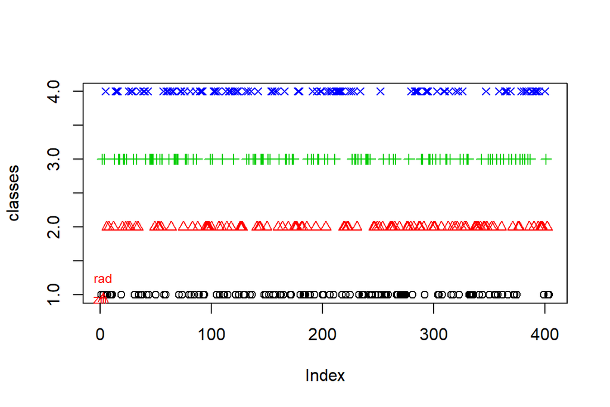

```r
lda.fit <- lda(crime ~ ., data = train)
lda.arrows <- function(x, myscale = 1, arrow_heads = 0.1, color = "red", tex = 0.75, choices = c(1,2)){
  heads <- coef(x)
  arrows(x0 = 0, y0 = 0,
         x1 = myscale * heads[,choices[1]],
         y1 = myscale * heads[,choices[2]], col=color, length = arrow_heads)
  text(myscale * heads[,choices], labels = row.names(heads),
       cex = tex, col=color, pos=3)
}

# target classes as numeric
classes <- as.numeric(train$crime)

# plot the lda results
plot(classes, dimen = 2, col = classes, pch = classes)
lda.arrows(lda.fit, myscale = 1)
```

```r
# save the correct classes from test data
correct_classes <- test$crime

# remove the crime variable from test data
test <- dplyr::select(test, -crime)

lda.pred <- predict(lda.fit, newdata = test)
table(correct = correct_classes, predicted = lda.pred$class)
```

```
##           predicted
## correct    low med_low med_high high
##   low       11       8        0    0
##   med_low    7      19        2    0
##   med_high   1       6       18    1
##   high       0       0        0   29
```

```r
# load MASS and Boston
library(MASS)
data('Boston')
scaled_boston <- scale(Boston)
# euclidean distance matrix
dist_eu <- dist(scaled_boston)
summary(dist_eu)
```

```
##    Min. 1st Qu.  Median    Mean 3rd Qu.    Max.
##  0.1343  3.4625  4.8241  4.9111  6.1863 14.3970
```

```r
# manhattan distance matrix
dist_man <- dist(scaled_boston, method = 'manhattan')
summary(dist_man)
```

```
##    Min. 1st Qu.  Median    Mean 3rd Qu.    Max.
##  0.2662  8.4832 12.6090 13.5488 17.7568 48.8618
```

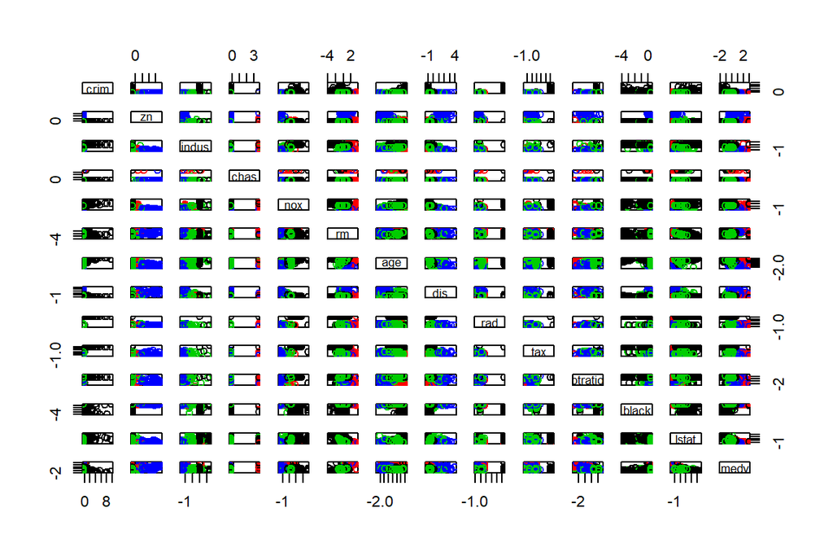

```r
km <-kmeans(scaled_boston, centers = 4)
pairs(scaled_boston, col = km$cluster)
```

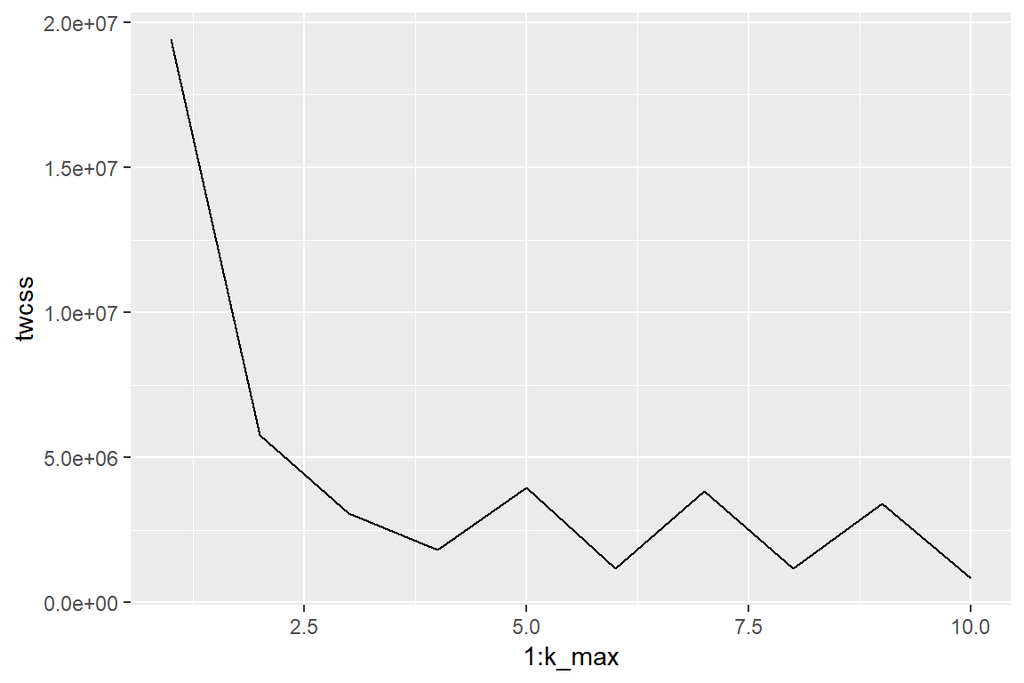

```r
set.seed(123)
k_max <- 10
twcss <- sapply(1:k_max, function(k){kmeans(Boston, k)$tot.withinss})
library(ggplot2)
qplot(x = 1:k_max, y = twcss, geom = 'line')
```

```r
km <-kmeans(Boston, centers = 2)
pairs(Boston, col = km$cluster)
```

[output not shown]

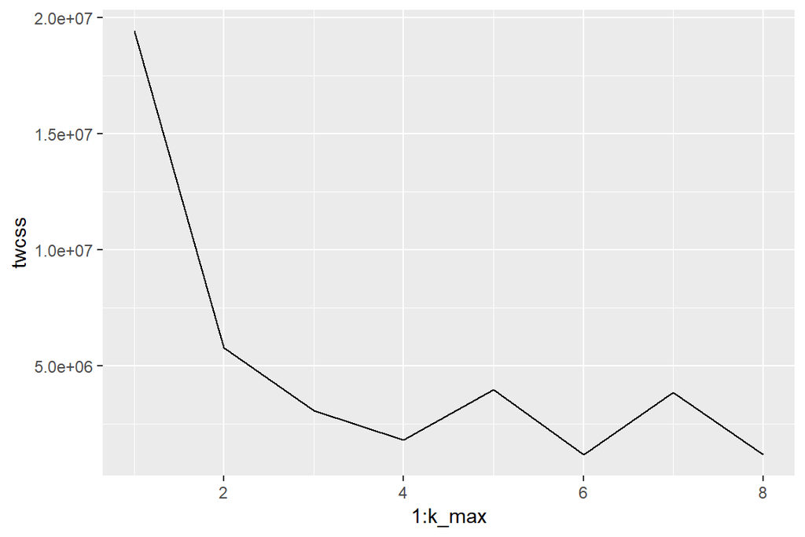

```r
set.seed(123)
k_max <- 8
twcss <- sapply(1:k_max, function(k){kmeans(Boston, k)$tot.withinss})
library(ggplot2)
qplot(x = 1:k_max, y = twcss, geom = 'line')
```

```r
km <-kmeans(Boston, centers = 2)
pairs(Boston, col = km$cluster)
```

[output not shown]

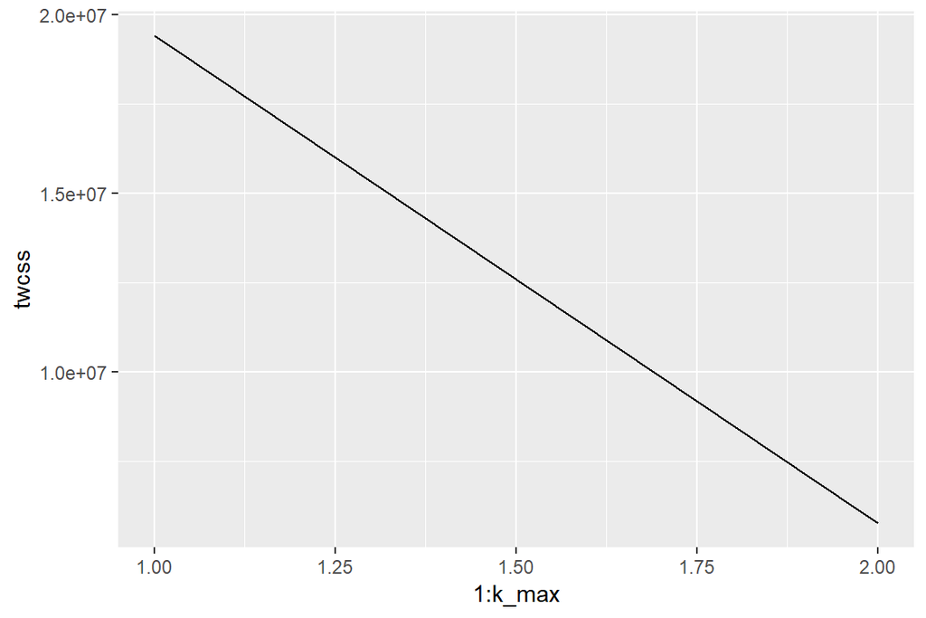

```r
set.seed(123)
k_max <- 2
twcss <- sapply(1:k_max, function(k){kmeans(Boston, k)$tot.withinss})
library(ggplot2)
qplot(x = 1:k_max, y = twcss, geom = 'line')
```

```r
km <-kmeans(Boston, centers = 2)
pairs(Boston, col = km$cluster)
```

[output not shown]

here, we can see that cluster 2 is optimal for this data. It seems that in claster 2, total within sum square cluster change much when total claster changes to 2.

# Dimentionaly reduction technique

1. read of the data

```r
human <- read.table(file = "C:/Users/ratul/Documents/GitHub/IODS-project/data/human.csv", sep = ",", header = T)
str(human)
```

```
## 'data.frame':    155 obs. of  9 variables:
##  $ X           : Factor w/ 155 levels "Afghanistan",..: 105 6 134 41 101 54 67 149 28 102 ...
##  $ EDU2_Ratio  : num  1.007 0.997 0.983 0.989 0.969 ...
##  $ Lab_Ratio   : num  0.891 0.819 0.825 0.884 0.829 ...
##  $ E_SCHOOL    : num  17.5 20.2 15.8 18.7 17.9 16.5 18.6 16.5 15.9 19.2 ...
##  $ LEB         : num  81.6 82.4 83 80.2 81.6 80.9 80.9 79.1 82 81.8 ...
##  $ GNI         : int  64992 42261 56431 44025 45435 43919 39568 52947 42155 32689 ...
##  $ MMR         : int  4 6 6 5 6 7 9 28 11 8 ...
##  $ ABR         : num  7.8 12.1 1.9 5.1 6.2 3.8 8.2 31 14.5 25.3 ...
##  $ PARLIAMENT_S: num  39.6 30.5 28.5 38 36.9 36.9 19.9 19.4 28.2 31.4 ...
```

```r
human$X <- NULL
str(human)
```

```
## 'data.frame':    155 obs. of  8 variables:
##  $ EDU2_Ratio  : num  1.007 0.997 0.983 0.989 0.969 ...
##  $ Lab_Ratio   : num  0.891 0.819 0.825 0.884 0.829 ...
##  $ E_SCHOOL    : num  17.5 20.2 15.8 18.7 17.9 16.5 18.6 16.5 15.9 19.2 ...
##  $ LEB         : num  81.6 82.4 83 80.2 81.6 80.9 80.9 79.1 82 81.8 ...
##  $ GNI         : int  64992 42261 56431 44025 45435 43919 39568 52947 42155 32689 ...
##  $ MMR         : int  4 6 6 5 6 7 9 28 11 8 ...
##  $ ABR         : num  7.8 12.1 1.9 5.1 6.2 3.8 8.2 31 14.5 25.3 ...
##  $ PARLIAMENT_S: num  39.6 30.5 28.5 38 36.9 36.9 19.9 19.4 28.2 31.4 ...
```

2. Graphical presentation of the data

```r
library(GGally)
```

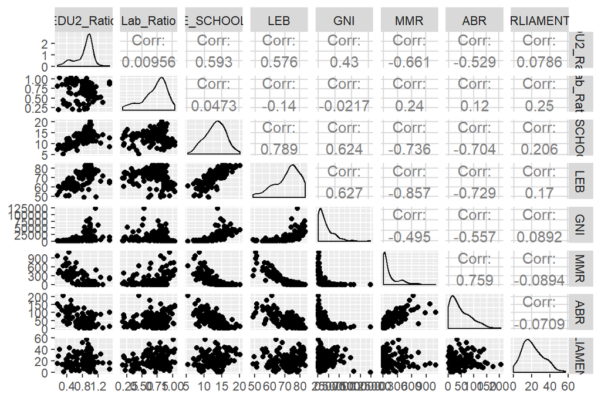

```r
ggpairs(human)
```

from the ggpairs we can see that all the variables have numeric values. Thats why we got scatter plots else we would get histogram if we had any categorial variable. from the above graph we can see that corelation between two variables. For example, there is a positive correlation between gross national income per capita and expected days in school. we can also see the relation through scatter plots and normal graphs.

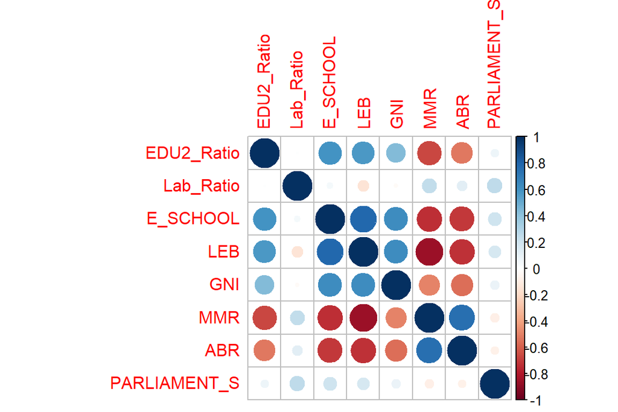

```r
library(corrplot)
library(dplyr)
library(ggplot2)

cor(human) %>% corrplot()
```

```r
summary(human)
```

```
##    EDU2_Ratio       Lab_Ratio         E_SCHOOL          LEB
##  Min.   :0.1717   Min.   :0.1857   Min.   : 5.40   Min.   :49.00
##  1st Qu.:0.7264   1st Qu.:0.5984   1st Qu.:11.25   1st Qu.:66.30
##  Median :0.9375   Median :0.7535   Median :13.50   Median :74.20
##  Mean   :0.8529   Mean   :0.7074   Mean   :13.18   Mean   :71.65
##  3rd Qu.:0.9968   3rd Qu.:0.8535   3rd Qu.:15.20   3rd Qu.:77.25
##  Max.   :1.4967   Max.   :1.0380   Max.   :20.20   Max.   :83.50
##       GNI              MMR              ABR          PARLIAMENT_S
##  Min.   :   581   Min.   :   1.0   Min.   :  0.60   Min.   : 0.00
##  1st Qu.:  4198   1st Qu.:  11.5   1st Qu.: 12.65   1st Qu.:12.40
##  Median : 12040   Median :  49.0   Median : 33.60   Median :19.30
##  Mean   : 17628   Mean   : 149.1   Mean   : 47.16   Mean   :20.91
##  3rd Qu.: 24512   3rd Qu.: 190.0   3rd Qu.: 71.95   3rd Qu.:27.95
##  Max.   :123124   Max.   :1100.0   Max.   :204.80   Max.   :57.50
```

we can also see the level of correlation between variables throgh this corrplot. here as previously described, LEB has positive correlation with GNI(light blue). we can see that male and female ration in parliament has very low correlation with other variables. from the summary we can the min and max value of variables and also other statistical figure. we can see that there is high difference in male/female education ration in countries and also per capita GNI is hugely differ from country to country.

3.principal component analysis

```r
library(dplyr)

pc_human <- prcomp(human)
summary(pc_human)
```

```
## Importance of components:
##                              PC1      PC2   PC3   PC4   PC5   PC6    PC7
## Standard deviation     1.854e+04 185.5219 25.19 11.45 3.766 1.566 0.1912
## Proportion of Variance 9.999e-01   0.0001  0.00  0.00 0.000 0.000 0.0000
## Cumulative Proportion  9.999e-01   1.0000  1.00  1.00 1.000 1.000 1.0000
##                           PC8
## Standard deviation     0.1591
## Proportion of Variance 0.0000
## Cumulative Proportion  1.0000
```

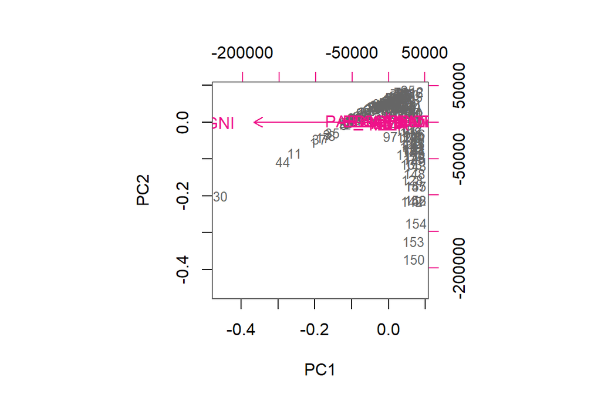

```r
biplot(pc_human, choices = 1:2, cex = c(0.8, 1), col = c("grey40", "deeppink2"))
```

This is a poor biplot of the data. The main idea of the biplot is by viewing the direction of angles one can have a idea about correaltion between different features. But here most of the angles are inderminate angle(we can see see them above the plot), and that because of data is not scales properly. The variance between variables differ hugely which might be a problem. so we need scaled data to biplot.

4. pca on standard data

```r
library(dplyr)
library(FactoMineR)
```

```r
library(ggplot2)
library(tidyr)
human_std <- scale(human)
summary(human_std)
```

```
##    EDU2_Ratio        Lab_Ratio          E_SCHOOL            LEB
##  Min.   :-2.8189   Min.   :-2.6247   Min.   :-2.7378   Min.   :-2.7188
##  1st Qu.:-0.5233   1st Qu.:-0.5484   1st Qu.:-0.6782   1st Qu.:-0.6425
##  Median : 0.3503   Median : 0.2316   Median : 0.1140   Median : 0.3056
##  Mean   : 0.0000   Mean   : 0.0000   Mean   : 0.0000   Mean   : 0.0000
##  3rd Qu.: 0.5958   3rd Qu.: 0.7350   3rd Qu.: 0.7126   3rd Qu.: 0.6717
##  Max.   : 2.6646   Max.   : 1.6632   Max.   : 2.4730   Max.   : 1.4218
##       GNI               MMR               ABR           PARLIAMENT_S
##  Min.   :-0.9193   Min.   :-0.6992   Min.   :-1.1325   Min.   :-1.8203
##  1st Qu.:-0.7243   1st Qu.:-0.6496   1st Qu.:-0.8394   1st Qu.:-0.7409
##  Median :-0.3013   Median :-0.4726   Median :-0.3298   Median :-0.1403
##  Mean   : 0.0000   Mean   : 0.0000   Mean   : 0.0000   Mean   : 0.0000
##  3rd Qu.: 0.3712   3rd Qu.: 0.1932   3rd Qu.: 0.6030   3rd Qu.: 0.6127
##  Max.   : 5.6890   Max.   : 4.4899   Max.   : 3.8344   Max.   : 3.1850
```

```r
pc_human_std <- prcomp(human_std)
summary(pc_human_std)
```

```
## Importance of components:
##                           PC1    PC2     PC3     PC4     PC5     PC6
## Standard deviation     2.0708 1.1397 0.87505 0.77886 0.66196 0.53631
## Proportion of Variance 0.5361 0.1624 0.09571 0.07583 0.05477 0.03595
## Cumulative Proportion  0.5361 0.6984 0.79413 0.86996 0.92473 0.96069
##                            PC7     PC8
## Standard deviation     0.45900 0.32224
## Proportion of Variance 0.02634 0.01298
## Cumulative Proportion  0.98702 1.00000
```

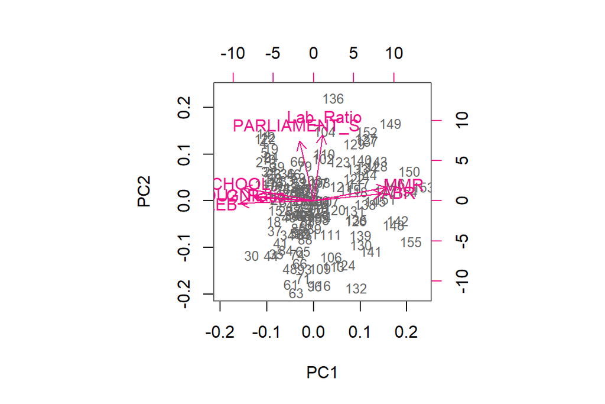

```r
biplot(pc_human_std, choices = 1:2, cex = c(0.8, 1), col = c("grey40", "deeppink2"))
```

here we can see far more better biplot than the previous one. Here we can see the angles and their direction to the different pc. The results are different. this is because we scaled the data. If we see the summary of two data we can easily seen the difference. After scaling there is a very less difference in min and maximum value than earlier. Also the mean in all variables is same. so what we did, we reduce the dimension of the data and we can see clear arrows as correlation between variables.

we can create three groups of variable those are relate to each other in same group. 1st group or quality of life in relation with basic foundation: expected days in school, Gross national income per capita, expentacy of life and male/female ratio in school. 2nd group or female participation in economy: female participation in parliament and male/female ratio in labour 3rd group or female reproduction quality : maternal mortality rate and adolescent birth rate.

from the bioplot, the smaller the space between two angles the larger the correlation. so here we can large corelation between each variables in one group. Elsewise, there is a negative or no correlation between variables from two groups as space is higher. For example female participation in parliament has negative correlation with maternal mortality rate.

5. from the biplot we can see that group 1 or quality of life in relation with basic foundation is negatively related with pc1 and almost no correlation with pc2. 2nd group or female participation in economy has positive correlation with pc2 and amost zero correlation with pc1. 3rd group or female reproduction quality has positive corelation with pc1 and almost zero correlation with pc2. contribution to pc1 and pc2: so if the features directed to way pc1 directed are pc1 component and if the features directed to way pc2 directed are pc2 component. Here group 1 and 3 are contributing to pc1 components and group2 contributing to pc2 components. From the summary we can say that, pc1 has 0.53 proportion of variance and pc2 has 0.16 proportion of variance. Alltogether they are 0.69, which means this bioplot can explain almost 70% of variance in different countries.

```r
library(FactoMineR)
library(ggplot2)
library(tidyr)
tea <- read.table("http://factominer.free.fr/course/donnees/data_MCA_Tea.csv", sep=";", header=TRUE)
dim(tea)
```

```
## [1] 300  36
```

```r
str(tea)
```

```
## 'data.frame':    300 obs. of  36 variables:
##  $ breakfast       : Factor w/ 2 levels "breakfast","Not.breakfast": 1 1 2 2 1 2 1 2 1 1 ...
##  $ tea.time        : Factor w/ 2 levels "Not.tea time",..: 1 1 2 1 1 1 2 2 2 1 ...
##  $ evening         : Factor w/ 2 levels "evening","Not.evening": 2 2 1 2 1 2 2 1 2 1 ...
##  $ lunch           : Factor w/ 2 levels "lunch","Not.lunch": 2 2 2 2 2 2 2 2 2 2 ...
##  $ dinner          : Factor w/ 2 levels "dinner","Not.dinner": 2 2 1 1 2 1 2 2 2 2 ...
##  $ always          : Factor w/ 2 levels "always","Not.always": 2 2 2 2 1 2 2 2 2 2 ...
##  $ home            : Factor w/ 2 levels "home","Not.home": 1 1 1 1 1 1 1 1 1 1 ...
##  $ work            : Factor w/ 2 levels "Not.work","work": 1 1 2 1 1 1 1 1 1 1 ...
##  $ tearoom         : Factor w/ 2 levels "Not.tearoom",..: 1 1 1 1 1 1 1 1 1 2 ...
##  $ friends         : Factor w/ 2 levels "friends","Not.friends": 2 2 1 2 2 2 1 2 2 2 ...
##  $ resto           : Factor w/ 2 levels "Not.resto","resto": 1 1 2 1 1 1 1 1 1 1 ...
##  $ pub             : Factor w/ 2 levels "Not.pub","pub": 1 1 1 1 1 1 1 1 1 1 ...
##  $ Tea             : Factor w/ 3 levels "black","Earl Grey",..: 1 1 2 2 2 2 2 1 2 1 ...
##  $ How             : Factor w/ 4 levels "alone","lemon",..: 1 3 1 1 1 1 1 3 3 1 ...
```

[output cut: 22 more lines]

```r
summary(tea)
```

```
##          breakfast           tea.time          evening          lunch
##  breakfast    :144   Not.tea time:131   evening    :103   lunch    : 44
##  Not.breakfast:156   tea time    :169   Not.evening:197   Not.lunch:256
##
##
##
##
##
##         dinner           always          home           work
##  dinner    : 21   always    :103   home    :291   Not.work:213
##  Not.dinner:279   Not.always:197   Not.home:  9   work    : 87
##
##
##
##
##
##         tearoom           friends          resto          pub
##  Not.tearoom:242   friends    :196   Not.resto:221   Not.pub:237
##  tearoom    : 58   Not.friends:104   resto    : 79   pub    : 63
##
##
##
##
##
##         Tea         How           sugar                     how
##  black    : 74   alone:195   No.sugar:155   tea bag           :170
##  Earl Grey:193   lemon: 33   sugar   :145   tea bag+unpackaged: 94
##  green    : 33   milk : 63                  unpackaged        : 36
##                  other:  9
##
##
##
##                   where                 price          age        sex
##  chain store         :192   p_branded      : 95   Min.   :15.00   F:178
##  chain store+tea shop: 78   p_cheap        :  7   1st Qu.:23.00   M:122
##  tea shop            : 30   p_private label: 21   Median :32.00
##                             p_unknown      : 12   Mean   :37.05
##                             p_upscale      : 53   3rd Qu.:48.00
##                             p_variable     :112   Max.   :90.00
##
```

[output cut: 25 more lines]

```
##  feminine    :129   Not.sophisticated: 85   No.slimming:255
##  Not.feminine:171   sophisticated    :215   slimming   : 45
##
##
##
##
##
##         exciting          relaxing              effect.on.health
##  exciting   :116   No.relaxing:113   effect on health   : 66
##  No.exciting:184   relaxing   :187   No.effect on health:234
##
##
##
##
##
```

```r
keep_columns <- c("Sport", "slimming", "relaxing", "healthy", "sugar", "effect.on.health")
tea_time <- dplyr::select(tea, one_of(keep_columns))
mca <- MCA(tea_time, graph = FALSE)
summary(mca)
```

```
##
## Call:
## MCA(X = tea_time, graph = FALSE)
##
##
## Eigenvalues
##                        Dim.1   Dim.2   Dim.3   Dim.4   Dim.5   Dim.6
## Variance               0.231   0.196   0.176   0.162   0.139   0.098
## % of var.             23.073  19.550  17.558  16.158  13.856   9.804
## Cumulative % of var.  23.073  42.624  60.182  76.340  90.196 100.000
##
## Individuals (the 10 first)
##                  Dim.1    ctr   cos2    Dim.2    ctr   cos2    Dim.3
## 1             | -0.081  0.009  0.009 | -0.218  0.081  0.067 | -0.264
## 2             | -0.129  0.024  0.024 |  0.265  0.120  0.102 | -0.400
## 3             | -0.405  0.237  0.318 | -0.117  0.023  0.026 | -0.056
## 4             | -0.365  0.192  0.198 | -0.254  0.110  0.096 | -0.166
## 5             |  0.209  0.063  0.052 | -0.284  0.138  0.097 | -0.061
## 6             | -0.405  0.237  0.318 | -0.117  0.023  0.026 | -0.056
## 7             | -0.405  0.237  0.318 | -0.117  0.023  0.026 | -0.056
## 8             | -0.405  0.237  0.318 | -0.117  0.023  0.026 | -0.056
## 9             |  0.209  0.063  0.052 | -0.284  0.138  0.097 | -0.061
## 10            | -0.414  0.247  0.263 |  0.230  0.090  0.081 | -0.302
##                  ctr   cos2
## 1              0.133  0.098 |
## 2              0.304  0.232 |
## 3              0.006  0.006 |
## 4              0.052  0.041 |
## 5              0.007  0.004 |
## 6              0.006  0.006 |
## 7              0.006  0.006 |
## 8              0.006  0.006 |
## 9              0.007  0.004 |
## 10             0.173  0.140 |
##
## Categories (the 10 first)
##                   Dim.1     ctr    cos2  v.test     Dim.2     ctr    cos2
## Not.sportsman |  -0.014   0.006   0.000  -0.201 |   0.548  10.337   0.203
## sportsman     |   0.010   0.004   0.000   0.201 |  -0.371   6.988   0.203
## No.slimming   |   0.101   0.632   0.058   4.175 |  -0.204   3.021   0.236
```

[output cut: 12 more lines]

```
## No.relaxing     8.494 |  -0.539  10.398   0.176  -7.249 |
## relaxing       -8.494 |   0.326   6.283   0.176   7.249 |
## healthy         3.521 |   0.003   0.001   0.000   0.087 |
## Not.healthy    -3.521 |  -0.008   0.002   0.000  -0.087 |
## No.sugar       11.083 |  -0.165   1.343   0.029  -2.958 |
## sugar         -11.083 |   0.177   1.435   0.029   2.958 |
##
## Categorical variables (eta2)
##                    Dim.1 Dim.2 Dim.3
## Sport            | 0.000 0.203 0.092 |
## slimming         | 0.058 0.236 0.546 |
## relaxing         | 0.149 0.241 0.176 |
## healthy          | 0.659 0.041 0.000 |
## sugar            | 0.005 0.411 0.029 |
## effect.on.health | 0.514 0.040 0.210 |
```

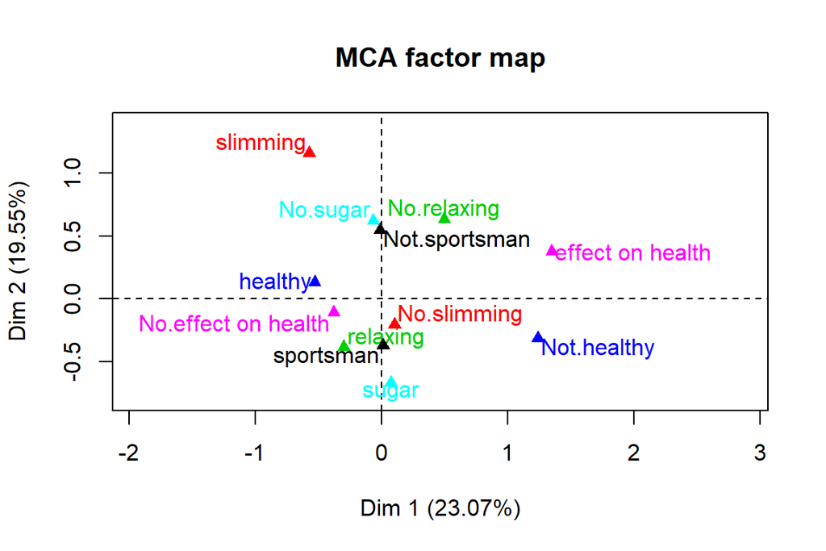

```r
plot(mca, invisible=c("ind"), habillage="quali")
```

# Longitudinal data Anaysis

1. RATS data Analysis according to chapter 8…

```r
RATS <- read.table("https://raw.githubusercontent.com/KimmoVehkalahti/MABS/master/Examples/data/rats.txt", sep = '', header = T)
library(ggplot2)
library(dplyr)
library(tidyr)
RATS$ID <- factor(RATS$ID)
RATS$Group<- factor(RATS$Group)

RATSL <-  RATS %>% gather(key = WD, value = weight, -ID, -Group)
RATSL <-  RATSL %>% mutate(Time = as.integer(substr(WD,3,4)))
glimpse(RATSL)
```

```
## Observations: 176
## Variables: 5
## $ ID     <fct> 1, 2, 3, 4, 5, 6, 7, 8, 9, 10, 11, 12, 13, 14, 15, 16, ...
## $ Group  <fct> 1, 1, 1, 1, 1, 1, 1, 1, 2, 2, 2, 2, 3, 3, 3, 3, 1, 1, 1...
## $ WD     <chr> "WD1", "WD1", "WD1", "WD1", "WD1", "WD1", "WD1", "WD1",...
## $ weight <int> 240, 225, 245, 260, 255, 260, 275, 245, 410, 405, 445, ...
## $ Time   <int> 1, 1, 1, 1, 1, 1, 1, 1, 1, 1, 1, 1, 1, 1, 1, 1, 8, 8, 8...
```

```r
str(RATSL)
```

```
## 'data.frame':    176 obs. of  5 variables:
##  $ ID    : Factor w/ 16 levels "1","2","3","4",..: 1 2 3 4 5 6 7 8 9 10 ...
##  $ Group : Factor w/ 3 levels "1","2","3": 1 1 1 1 1 1 1 1 2 2 ...
##  $ WD    : chr  "WD1" "WD1" "WD1" "WD1" ...
##  $ weight: int  240 225 245 260 255 260 275 245 410 405 ...
##  $ Time  : int  1 1 1 1 1 1 1 1 1 1 ...
```

The RATSL data contain 176 observation and 5 variables after processing of wide RATS data. Let’s graphically present the data.

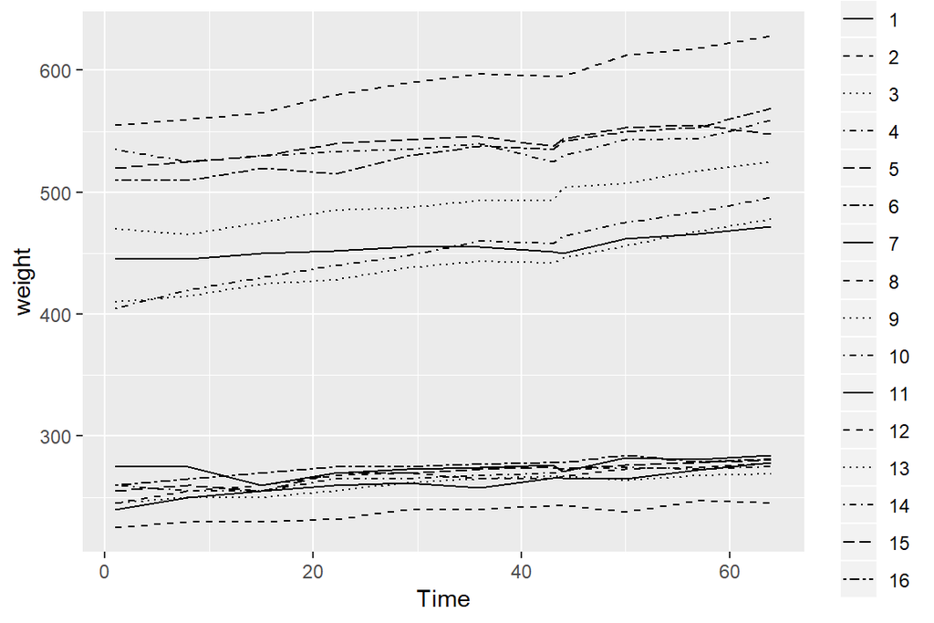

```r
p1 <- ggplot(RATSL, aes(x = Time, y = weight, linetype = ID))
p2 <- p1 + geom_line() + scale_linetype_manual(values = rep(1:10, times=4))
p2
```

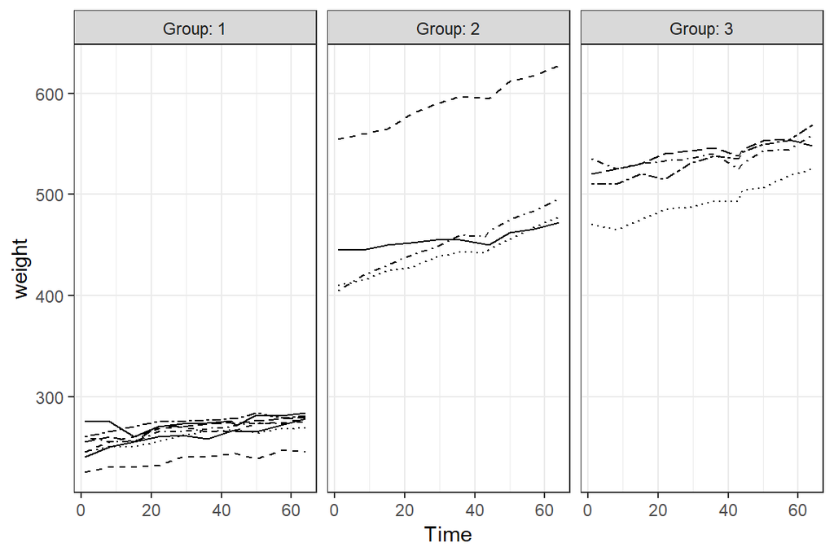

```r
p3 <- p2 + facet_grid(. ~ Group, labeller = label_both)
p4 <- p3 + theme_bw() + theme(legend.position = "none")
p5 <- p4 + theme(panel.grid.minor.y = element_blank())
p6 <- p5 + scale_y_continuous(limits = c(min(RATSL$weight), max(RATSL$weight)))
p6
```

```r
# Standardise the weight:
RATSL <- RATSL %>%
  group_by(Time) %>%
  mutate( stdweight = (weight - mean(weight))/sd(weight) ) %>%
  ungroup()
glimpse(RATSL)
```

```
## Observations: 176
## Variables: 6
## $ ID        <fct> 1, 2, 3, 4, 5, 6, 7, 8, 9, 10, 11, 12, 13, 14, 15, 1...
## $ Group     <fct> 1, 1, 1, 1, 1, 1, 1, 1, 2, 2, 2, 2, 3, 3, 3, 3, 1, 1...
## $ WD        <chr> "WD1", "WD1", "WD1", "WD1", "WD1", "WD1", "WD1", "WD...
## $ weight    <int> 240, 225, 245, 260, 255, 260, 275, 245, 410, 405, 44...
## $ Time      <int> 1, 1, 1, 1, 1, 1, 1, 1, 1, 1, 1, 1, 1, 1, 1, 1, 8, 8...
## $ stdweight <dbl> -1.0011429, -1.1203857, -0.9613953, -0.8421525, -0.8...
```

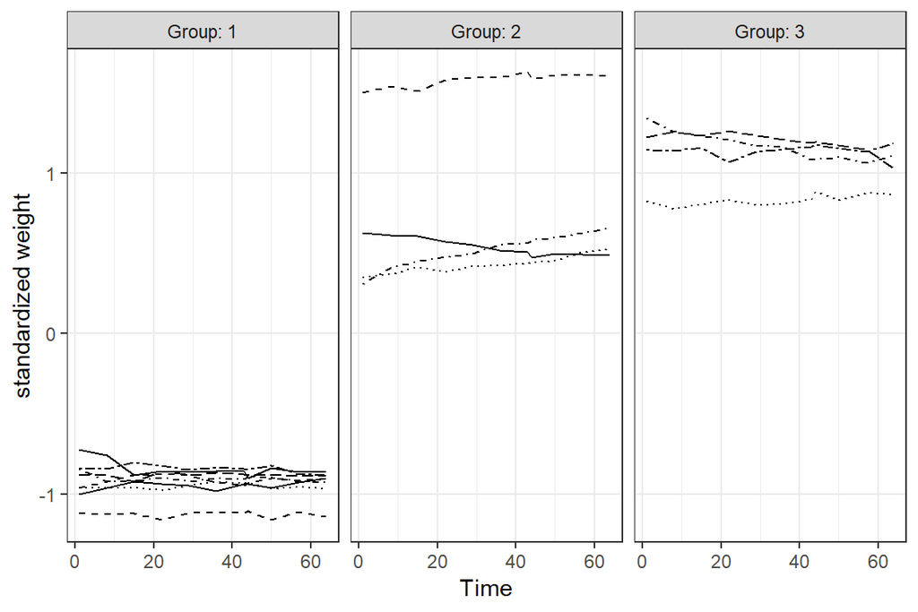

```r
p1 <- ggplot(RATSL, aes(x = Time, y = stdweight, linetype = ID))
p2 <- p1 + geom_line() + scale_linetype_manual(values = rep(1:10, times=4))
p3 <- p2 + facet_grid(. ~ Group, labeller = label_both)
p4 <- p3 + theme_bw() + theme(legend.position = "none")
p5 <- p4 + theme(panel.grid.minor.y = element_blank())
p6 <- p5 + scale_y_continuous(name = "standardized weight")
p6
```

Now the graphs look more linear as we use standard weight. weight are much higher in group 2 and 3 compare to group 1. But in group 1 weight observation are more organized than group 2 and 3. Here data are more closed. But in group 2, we can see one line of data clearly making data isignificant.

```r
# Number of Times, baseline (Time 0) included:
n <- RATSL$Time %>% unique() %>% length()
# Make a summary data:
RATSS <- RATSL %>%
  group_by(Group, Time) %>%
  summarise( mean=mean(weight), se=sd(weight)/sqrt(n) ) %>%
  ungroup()
glimpse(RATSS)
```

```
## Observations: 33
## Variables: 4
## $ Group <fct> 1, 1, 1, 1, 1, 1, 1, 1, 1, 1, 1, 2, 2, 2, 2, 2, 2, 2, 2,...
## $ Time  <int> 1, 8, 15, 22, 29, 36, 43, 44, 50, 57, 64, 1, 8, 15, 22, ...
## $ mean  <dbl> 250.625, 255.000, 254.375, 261.875, 264.625, 265.000, 26...
## $ se    <dbl> 4.589478, 3.947710, 3.460116, 4.100800, 3.333956, 3.5529...
```

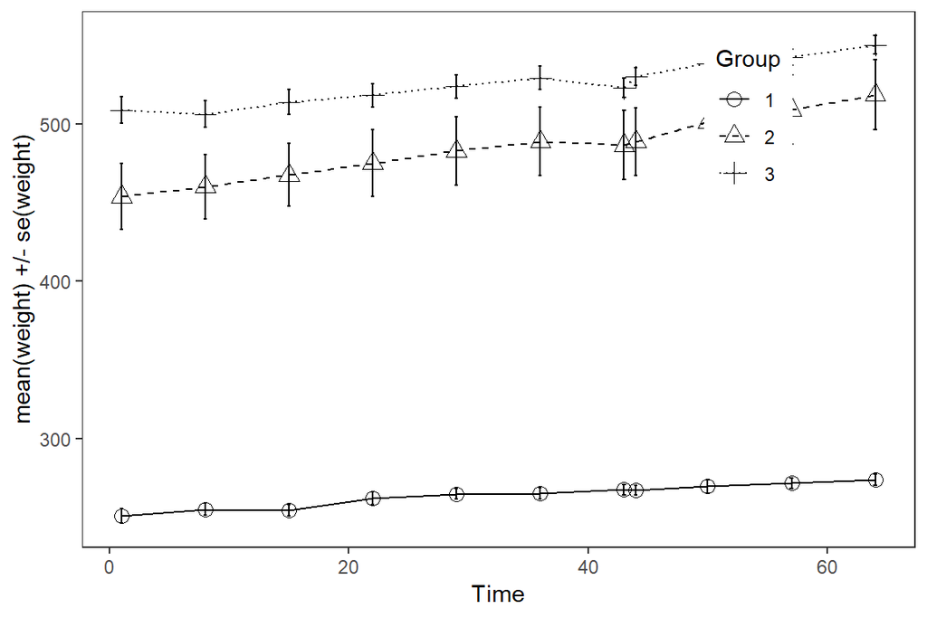

```r
p1 <- ggplot(RATSS, aes(x = Time, y = mean, linetype = Group, shape = Group))
p2 <- p1 + geom_line() + scale_linetype_manual(values = c(1:3))
p3 <- p2 + geom_point(size=3) + scale_shape_manual(values = c(1:3))
p4 <- p3 + geom_errorbar(aes(ymin=mean-se, ymax=mean+se, linetype="1"), width=0.3)
p5 <- p4 + theme_bw() + theme(panel.grid.major = element_blank(), panel.grid.minor = element_blank())
p6 <- p5 + theme(legend.position = c(0.8,0.8))
p7 <- p6 + scale_y_continuous(name = "mean(weight) +/- se(weight)")
p7
```

here, mean weight are presented along with time interval for 3 Groups.

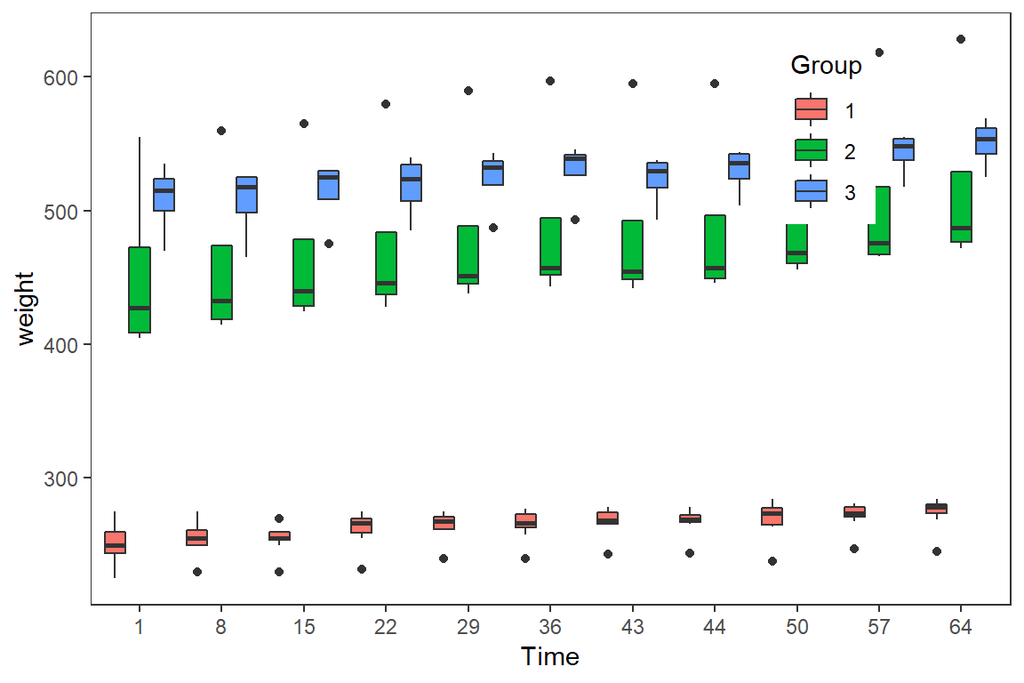

```r
p1 <- ggplot(RATSL, aes(x = factor(Time), y = weight, fill = Group))
p2 <- p1 + geom_boxplot(position = position_dodge(width = 0.9))
p3 <- p2 + theme_bw() + theme(panel.grid.major = element_blank(), panel.grid.minor = element_blank())
p4 <- p3 + theme(legend.position = c(0.8,0.8))
p5 <- p4 + scale_x_discrete(name = "Time")
# Black & White version:
#p6 <- p5 + scale_fill_grey(start = 0.5, end = 1)
p5
```

Boxplot presentation of weight for 3 groups.

```r
RATSL8S <- RATSL %>%
  filter(Time > 0) %>%
  group_by(Group, ID) %>%
  summarise( mean=mean(weight) ) %>%
  ungroup()
glimpse(RATSL8S)
```

```
## Observations: 16
## Variables: 3
## $ Group <fct> 1, 1, 1, 1, 1, 1, 1, 1, 2, 2, 2, 2, 3, 3, 3, 3
## $ ID    <fct> 1, 2, 3, 4, 5, 6, 7, 8, 9, 10, 11, 12, 13, 14, 15, 16
## $ mean  <dbl> 261.0909, 237.6364, 260.1818, 266.5455, 269.4545, 274.72...
```

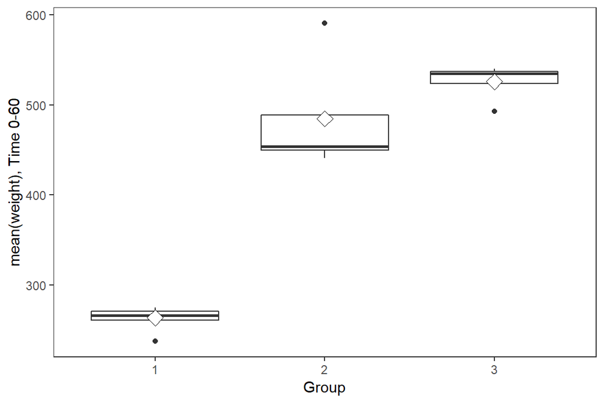

```r
p1 <- ggplot(RATSL8S, aes(x = Group, y = mean))
p2 <- p1 + geom_boxplot()
p3 <- p2 + theme_bw() + theme(panel.grid.major = element_blank(), panel.grid.minor = element_blank())
p4 <- p3 + stat_summary(fun.y = "mean", geom = "point", shape=23, size=4, fill = "white")
p5 <- p4 + scale_y_continuous(name = "mean(weight), Time 0-60")
p5
```

Applying the summary measure approach. From the graph we can see that, only group 1 is less variable in distribution compare to group 2 and 3. Perhaps, all the groups have outliers which create the bias in making conclusion of the data. Lets remove those outliers and see what happens.

```r
# Remove the outlier:
RATSL8S1 <- RATSL8S %>%
  filter(mean < 550)
glimpse(RATSL8S1)
```

```
## Observations: 15
## Variables: 3
## $ Group <fct> 1, 1, 1, 1, 1, 1, 1, 1, 2, 2, 2, 3, 3, 3, 3
## $ ID    <fct> 1, 2, 3, 4, 5, 6, 7, 8, 9, 10, 11, 13, 14, 15, 16
## $ mean  <dbl> 261.0909, 237.6364, 260.1818, 266.5455, 269.4545, 274.72...
```

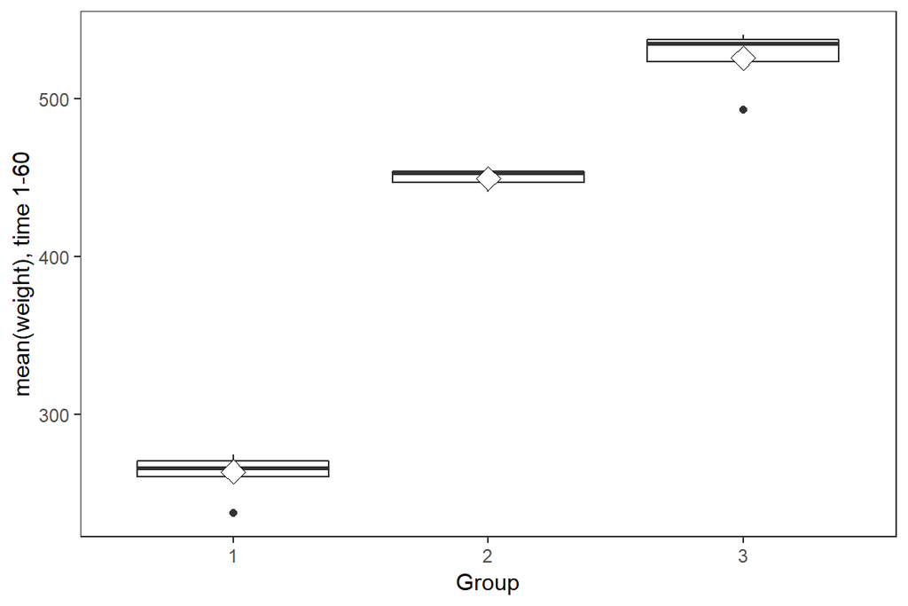

```r
p1 <- ggplot(RATSL8S1, aes(x = Group, y = mean))
p2 <- p1 + geom_boxplot()
p3 <- p2 + theme_bw() + theme(panel.grid.major = element_blank(), panel.grid.minor = element_blank())
p4 <- p3 + stat_summary(fun.y = "mean", geom = "point", shape=23, size=4, fill = "white")
p5 <- p4 + scale_y_continuous(name = "mean(weight), time 1-60")
p5
```

We are only keeping observations those are less than 550 mean weight. But still we have outliers in group 1 and 3.

```r
RATSL8S2 <- RATSL8S1 %>%
  filter(mean > 250)
glimpse(RATSL8S2)
```

```
## Observations: 14
## Variables: 3
## $ Group <fct> 1, 1, 1, 1, 1, 1, 1, 2, 2, 2, 3, 3, 3, 3
## $ ID    <fct> 1, 3, 4, 5, 6, 7, 8, 9, 10, 11, 13, 14, 15, 16
## $ mean  <dbl> 261.0909, 260.1818, 266.5455, 269.4545, 274.7273, 274.63...
```

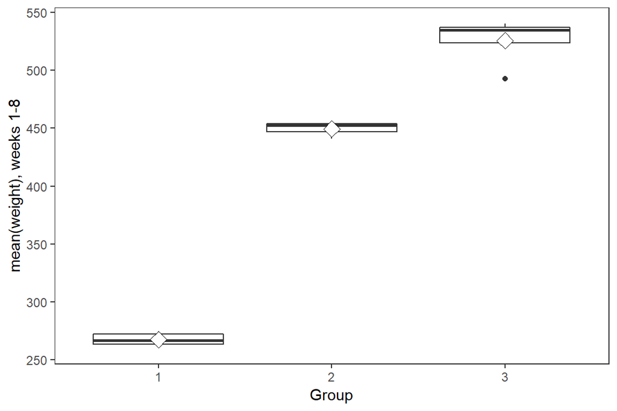

```r
p1 <- ggplot(RATSL8S2, aes(x = Group, y = mean))
p2 <- p1 + geom_boxplot()
p3 <- p2 + theme_bw() + theme(panel.grid.major = element_blank(), panel.grid.minor = element_blank())
p4 <- p3 + stat_summary(fun.y = "mean", geom = "point", shape=23, size=4, fill = "white")
p5 <- p4 + scale_y_continuous(name = "mean(weight), weeks 1-8")
p5
```

we are keeping observations those are more than 250 mean weight and now we have outliers only in 1 group.

```r
baseline <- RATS$WD1
RATSL8S3 <- RATSL8S %>%
  mutate(baseline)
# Fit the ANCOVA model and see the results:
fit <- lm(mean ~ baseline + Group, data = RATSL8S3)
summary(fit)
```

```
##
## Call:
## lm(formula = mean ~ baseline + Group, data = RATSL8S3)
##
## Residuals:
##     Min      1Q  Median      3Q     Max
## -21.732  -3.812   1.991   6.889  13.455
##
## Coefficients:
##             Estimate Std. Error t value Pr(>|t|)
## (Intercept) 30.14886   19.88779   1.516   0.1554
## baseline     0.93194    0.07793  11.959 5.02e-08 ***
## Group2      31.68866   17.11189   1.852   0.0888 .
## Group3      21.52296   21.13931   1.018   0.3287
## ---
## Signif. codes:  0 '***' 0.001 '**' 0.01 '*' 0.05 '.' 0.1 ' ' 1
##
## Residual standard error: 10.62 on 12 degrees of freedom
## Multiple R-squared:  0.9947, Adjusted R-squared:  0.9933
## F-statistic: 747.8 on 3 and 12 DF,  p-value: 6.636e-14
```

```r
anova(fit)
```

```
## Analysis of Variance Table
##
## Response: mean
##           Df Sum Sq Mean Sq   F value    Pr(>F)
## baseline   1 252125  252125 2237.0655 5.217e-15 ***
## Group      2    726     363    3.2219   0.07586 .
## Residuals 12   1352     113
## ---
## Signif. codes:  0 '***' 0.001 '**' 0.01 '*' 0.05 '.' 0.1 ' ' 1
```

As we have 3 groups so its not possible to t-test. From the ANOVA table we can see that the variance in weight is highly significant for baseline data. While group 2 is slightly signifact for weight variance. But Group3 haqs no significance.

2.BPRS data Analysis according to chapter 9

```r
BPRS <- read.table("https://raw.githubusercontent.com/KimmoVehkalahti/MABS/master/Examples/data/BPRS.txt", sep = '', header = T)

names(BPRS)
```

```
##  [1] "treatment" "subject"   "week0"     "week1"     "week2"
##  [6] "week3"     "week4"     "week5"     "week6"     "week7"
## [11] "week8"
```

```r
str(BPRS)
```

```
## 'data.frame':    40 obs. of  11 variables:
##  $ treatment: int  1 1 1 1 1 1 1 1 1 1 ...
##  $ subject  : int  1 2 3 4 5 6 7 8 9 10 ...
##  $ week0    : int  42 58 54 55 72 48 71 30 41 57 ...
##  $ week1    : int  36 68 55 77 75 43 61 36 43 51 ...
##  $ week2    : int  36 61 41 49 72 41 47 38 39 51 ...
##  $ week3    : int  43 55 38 54 65 38 30 38 35 55 ...
##  $ week4    : int  41 43 43 56 50 36 27 31 28 53 ...
##  $ week5    : int  40 34 28 50 39 29 40 26 22 43 ...
##  $ week6    : int  38 28 29 47 32 33 30 26 20 43 ...
##  $ week7    : int  47 28 25 42 38 27 31 25 23 39 ...
##  $ week8    : int  51 28 24 46 32 25 31 24 21 32 ...
```

```r
summary(BPRS)
```

```
##    treatment      subject          week0           week1
##  Min.   :1.0   Min.   : 1.00   Min.   :24.00   Min.   :23.00
##  1st Qu.:1.0   1st Qu.: 5.75   1st Qu.:38.00   1st Qu.:35.00
##  Median :1.5   Median :10.50   Median :46.00   Median :41.00
##  Mean   :1.5   Mean   :10.50   Mean   :48.00   Mean   :46.33
##  3rd Qu.:2.0   3rd Qu.:15.25   3rd Qu.:58.25   3rd Qu.:54.25
##  Max.   :2.0   Max.   :20.00   Max.   :78.00   Max.   :95.00
##      week2          week3           week4           week5
##  Min.   :26.0   Min.   :24.00   Min.   :20.00   Min.   :20.00
##  1st Qu.:32.0   1st Qu.:29.75   1st Qu.:28.00   1st Qu.:26.00
##  Median :38.0   Median :36.50   Median :34.50   Median :30.50
##  Mean   :41.7   Mean   :39.15   Mean   :36.35   Mean   :32.55
##  3rd Qu.:49.0   3rd Qu.:44.50   3rd Qu.:43.00   3rd Qu.:38.00
##  Max.   :75.0   Max.   :76.00   Max.   :66.00   Max.   :64.00
##      week6           week7          week8
##  Min.   :19.00   Min.   :18.0   Min.   :20.00
##  1st Qu.:22.75   1st Qu.:23.0   1st Qu.:22.75
##  Median :28.50   Median :30.0   Median :28.00
##  Mean   :31.23   Mean   :32.2   Mean   :31.43
##  3rd Qu.:37.00   3rd Qu.:38.0   3rd Qu.:35.25
##  Max.   :64.00   Max.   :62.0   Max.   :75.00
```

```r
library(dplyr)
library(tidyr)
library(ggplot2)

BPRS$subject <- factor(BPRS$subject)
BPRS$treatment <- factor(BPRS$treatment)


BPRSL <-  BPRS %>% gather(key = weeks, value = bprs, -treatment, -subject)
BPRSL <-  BPRSL %>% mutate(week = as.integer(substr(weeks,5,5)))

glimpse(BPRSL)
```

```
## Observations: 360
## Variables: 5
## $ treatment <fct> 1, 1, 1, 1, 1, 1, 1, 1, 1, 1, 1, 1, 1, 1, 1, 1, 1, 1...
## $ subject   <fct> 1, 2, 3, 4, 5, 6, 7, 8, 9, 10, 11, 12, 13, 14, 15, 1...
## $ weeks     <chr> "week0", "week0", "week0", "week0", "week0", "week0"...
## $ bprs      <int> 42, 58, 54, 55, 72, 48, 71, 30, 41, 57, 30, 55, 36, ...
## $ week      <int> 0, 0, 0, 0, 0, 0, 0, 0, 0, 0, 0, 0, 0, 0, 0, 0, 0, 0...
```

```r
str(BPRSL)
```

```
## 'data.frame':    360 obs. of  5 variables:
##  $ treatment: Factor w/ 2 levels "1","2": 1 1 1 1 1 1 1 1 1 1 ...
##  $ subject  : Factor w/ 20 levels "1","2","3","4",..: 1 2 3 4 5 6 7 8 9 10 ...
##  $ weeks    : chr  "week0" "week0" "week0" "week0" ...
##  $ bprs     : int  42 58 54 55 72 48 71 30 41 57 ...
##  $ week     : int  0 0 0 0 0 0 0 0 0 0 ...
```

The BPRSL data contain 360 observation and 5 variables after processing of wide BPRS data. Let’s graphically present the data.

```r
str(BPRS)
```

```
## 'data.frame':    40 obs. of  11 variables:
##  $ treatment: Factor w/ 2 levels "1","2": 1 1 1 1 1 1 1 1 1 1 ...
##  $ subject  : Factor w/ 20 levels "1","2","3","4",..: 1 2 3 4 5 6 7 8 9 10 ...
##  $ week0    : int  42 58 54 55 72 48 71 30 41 57 ...
##  $ week1    : int  36 68 55 77 75 43 61 36 43 51 ...
##  $ week2    : int  36 61 41 49 72 41 47 38 39 51 ...
##  $ week3    : int  43 55 38 54 65 38 30 38 35 55 ...
##  $ week4    : int  41 43 43 56 50 36 27 31 28 53 ...
##  $ week5    : int  40 34 28 50 39 29 40 26 22 43 ...
##  $ week6    : int  38 28 29 47 32 33 30 26 20 43 ...
##  $ week7    : int  47 28 25 42 38 27 31 25 23 39 ...
##  $ week8    : int  51 28 24 46 32 25 31 24 21 32 ...
```

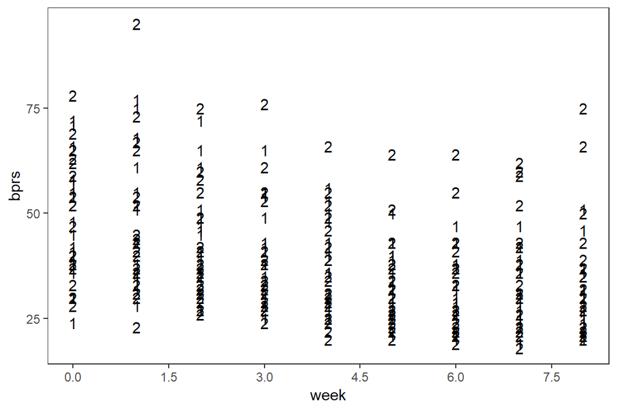

```r
p1 <- ggplot(BPRSL, aes(x = week, y = bprs, group = subject))
p2 <- p1 + geom_text(aes(label = treatment))
p3 <- p2 + scale_x_continuous(name = "week", breaks = seq(0, 8, 1.5))
p4 <- p3 + scale_y_continuous(name = "bprs")
p5 <- p4 + theme_bw()
p6 <- p5 + theme(panel.grid.major = element_blank(), panel.grid.minor = element_blank())
p6
```

```r
library(lme4)
BPRS_reg <- lm(bprs ~ week + treatment, data = BPRSL)
summary(BPRS_reg)
```

```
##
## Call:
## lm(formula = bprs ~ week + treatment, data = BPRSL)
##
## Residuals:
##     Min      1Q  Median      3Q     Max
## -22.454  -8.965  -3.196   7.002  50.244
##
## Coefficients:
##             Estimate Std. Error t value Pr(>|t|)
## (Intercept)  46.4539     1.3670  33.982   <2e-16 ***
## week         -2.2704     0.2524  -8.995   <2e-16 ***
## treatment2    0.5722     1.3034   0.439    0.661
## ---
## Signif. codes:  0 '***' 0.001 '**' 0.01 '*' 0.05 '.' 0.1 ' ' 1
##
## Residual standard error: 12.37 on 357 degrees of freedom
## Multiple R-squared:  0.1851, Adjusted R-squared:  0.1806
## F-statistic: 40.55 on 2 and 357 DF,  p-value: < 2.2e-16
```

[figure not shown]

```r
p1 <- ggplot(BPRSL, aes(x = week, y = bprs))
p1
```

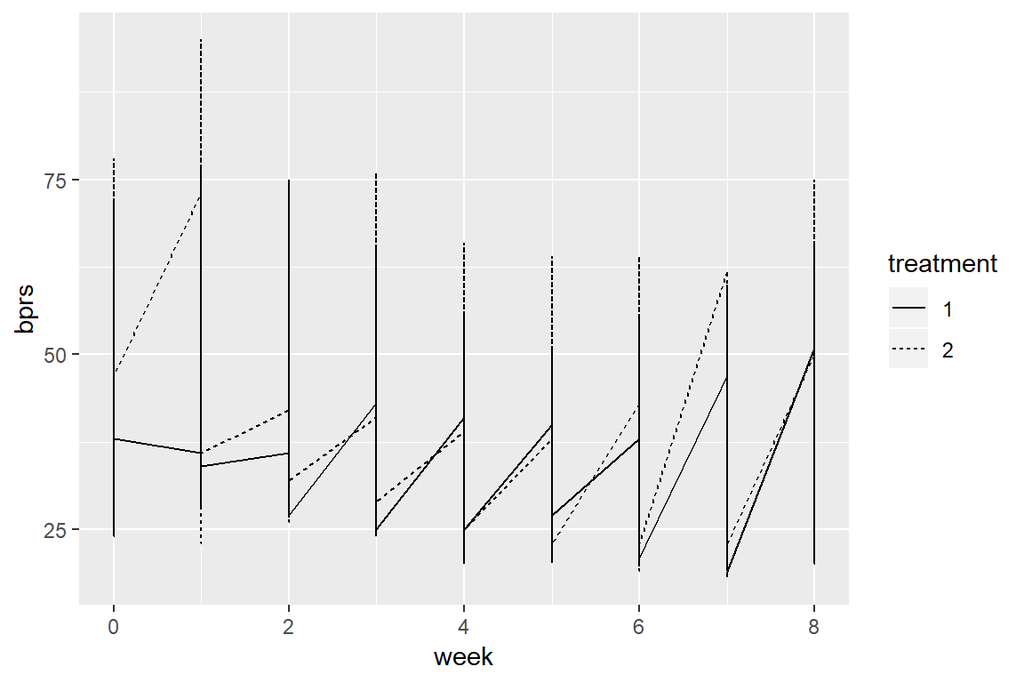

```r
p2 <- p1 + geom_line(aes(linetype = treatment))
p2
```

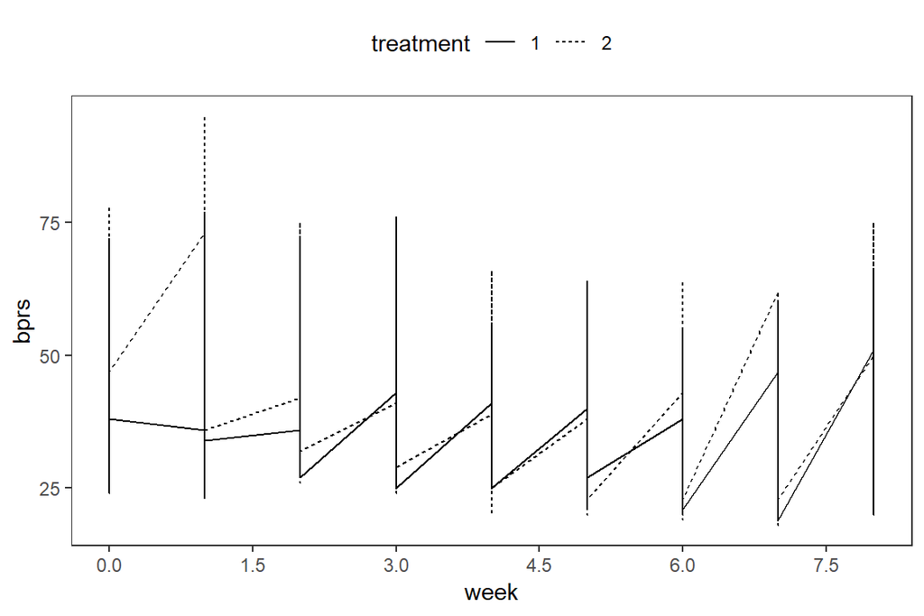

```r
p3 <- p2 + scale_x_continuous(name = "week", breaks = seq(0, 8, 1.5))
p4 <- p3 + scale_y_continuous(name = "bprs")
p5 <- p4 + theme_bw() + theme(legend.position = "top")
p6 <- p5 + theme(panel.grid.major = element_blank(), panel.grid.minor = element_blank())
p6
```

plot of individual bprs score against week.

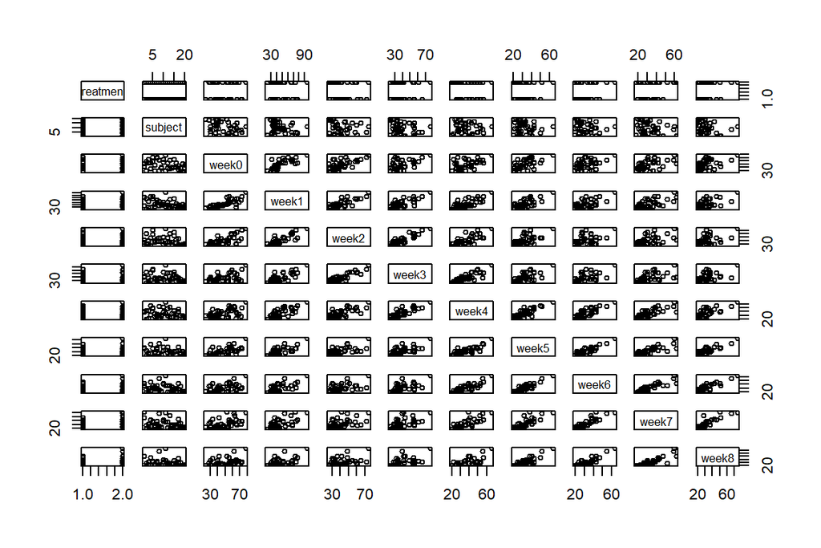

```r
pairs(BPRS[, 1:11], cex = 0.7)
```

scatter matrix of repeated measure of bprs scores in individual.

now, we are fitting the best liklihood linear models for our data.

```r
library("lme4")
BPRS_ref <- lmer(bprs ~ week + treatment + (1 | subject), data = BPRSL, REML = FALSE)
summary(BPRS_ref)
```

```
## Linear mixed model fit by maximum likelihood  ['lmerMod']
## Formula: bprs ~ week + treatment + (1 | subject)
##    Data: BPRSL
##
##      AIC      BIC   logLik deviance df.resid
##   2748.7   2768.1  -1369.4   2738.7      355
##
## Scaled residuals:
##     Min      1Q  Median      3Q     Max
## -3.0481 -0.6749 -0.1361  0.4813  3.4855
##
## Random effects:
##  Groups   Name        Variance Std.Dev.
##  subject  (Intercept)  47.41    6.885
##  Residual             104.21   10.208
## Number of obs: 360, groups:  subject, 20
##
## Fixed effects:
##             Estimate Std. Error t value
## (Intercept)  46.4539     1.9090  24.334
## week         -2.2704     0.2084 -10.896
## treatment2    0.5722     1.0761   0.532
##
## Correlation of Fixed Effects:
##            (Intr) week
## week       -0.437
## treatment2 -0.282  0.000
```

```r
# dummies (in Table) vs summary output: D1 = Group2, D2 = Group3
```

```r
BPRS_ref1 <- lmer(bprs ~ week + treatment + (week | subject), data = BPRSL, REML = FALSE)
summary(BPRS_ref1)
```

```
## Linear mixed model fit by maximum likelihood  ['lmerMod']
## Formula: bprs ~ week + treatment + (week | subject)
##    Data: BPRSL
##
##      AIC      BIC   logLik deviance df.resid
##   2745.4   2772.6  -1365.7   2731.4      353
##
## Scaled residuals:
##     Min      1Q  Median      3Q     Max
## -2.8919 -0.6194 -0.0691  0.5531  3.7976
##
## Random effects:
##  Groups   Name        Variance Std.Dev. Corr
##  subject  (Intercept) 64.8202  8.0511
##           week         0.9608  0.9802   -0.51
##  Residual             97.4307  9.8707
## Number of obs: 360, groups:  subject, 20
##
## Fixed effects:
##             Estimate Std. Error t value
## (Intercept)  46.4539     2.1052  22.066
## week         -2.2704     0.2977  -7.626
## treatment2    0.5722     1.0405   0.550
##
## Correlation of Fixed Effects:
##            (Intr) week
## week       -0.582
## treatment2 -0.247  0.000
```

```r
# dummies (in Table) vs summary output: D1 = Group2, D2 = Group3
anova(BPRS_ref1, BPRS_ref)
```

```
## Data: BPRSL
## Models:
## BPRS_ref: bprs ~ week + treatment + (1 | subject)
## BPRS_ref1: bprs ~ week + treatment + (week | subject)
##           Df    AIC    BIC  logLik deviance  Chisq Chi Df Pr(>Chisq)
## BPRS_ref   5 2748.7 2768.1 -1369.4   2738.7
## BPRS_ref1  7 2745.4 2772.6 -1365.7   2731.4 7.2721      2    0.02636 *
## ---
## Signif. codes:  0 '***' 0.001 '**' 0.01 '*' 0.05 '.' 0.1 ' ' 1
```

Compare to our 1st model, the 2nd model is more significant in describing variance in bprs score. But in both model treatment has no effect on scores while week(time period) seems significant negative relation with scores. As time goes scores decrease. Lets fit another model and compare it with 2nd model.

```r
BPRS_ref2 <- lmer(bprs ~ week * treatment + (week | subject), data = BPRSL, REML = FALSE)
summary(BPRS_ref2)
```

```
## Linear mixed model fit by maximum likelihood  ['lmerMod']
## Formula: bprs ~ week * treatment + (week | subject)
##    Data: BPRSL
##
##      AIC      BIC   logLik deviance df.resid
##   2744.3   2775.4  -1364.1   2728.3      352
##
## Scaled residuals:
##     Min      1Q  Median      3Q     Max
## -3.0512 -0.6271 -0.0767  0.5288  3.9260
##
## Random effects:
##  Groups   Name        Variance Std.Dev. Corr
##  subject  (Intercept) 65.0016  8.0624
##           week         0.9688  0.9843   -0.51
##  Residual             96.4699  9.8219
## Number of obs: 360, groups:  subject, 20
##
## Fixed effects:
##                 Estimate Std. Error t value
## (Intercept)      47.8856     2.2522  21.262
## week             -2.6283     0.3589  -7.323
## treatment2       -2.2911     1.9090  -1.200
## week:treatment2   0.7158     0.4010   1.785
##
## Correlation of Fixed Effects:
##             (Intr) week   trtmn2
## week        -0.650
## treatment2  -0.424  0.469
## wek:trtmnt2  0.356 -0.559 -0.840
```

```r
anova(BPRS_ref1, BPRS_ref2)
```

```
## Data: BPRSL
## Models:
## BPRS_ref1: bprs ~ week + treatment + (week | subject)
## BPRS_ref2: bprs ~ week * treatment + (week | subject)
##           Df    AIC    BIC  logLik deviance  Chisq Chi Df Pr(>Chisq)
## BPRS_ref1  7 2745.4 2772.6 -1365.7   2731.4
## BPRS_ref2  8 2744.3 2775.4 -1364.1   2728.3 3.1712      1    0.07495 .
## ---
## Signif. codes:  0 '***' 0.001 '**' 0.01 '*' 0.05 '.' 0.1 ' ' 1
```

model 3 is not very much effective compare to model 2. Lets keep model 2 and fit the model.

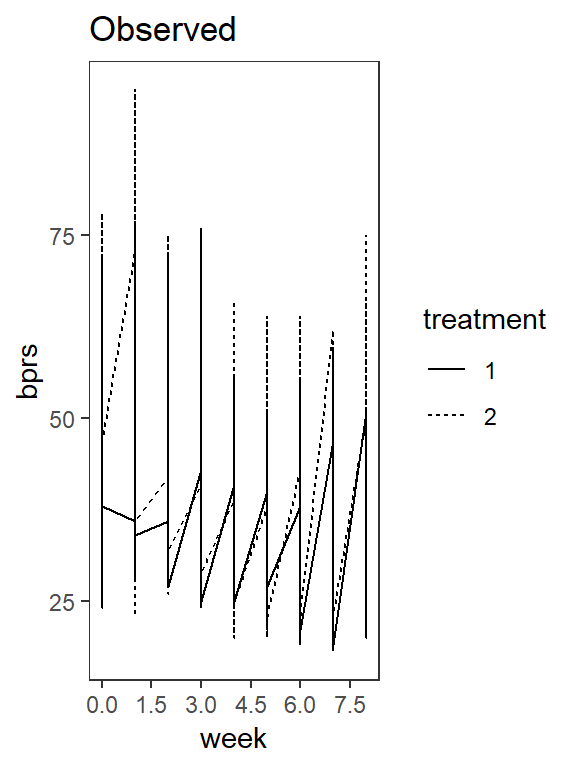

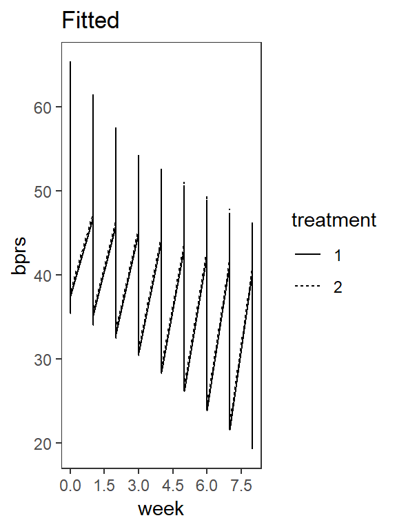

```r
Fitted <- fitted(BPRS_ref1)
BPRSL <- BPRSL %>% mutate(Fitted)
p1 <- ggplot(BPRSL, aes(x = week, y = bprs))
p2 <- p1 + geom_line(aes(linetype = treatment))
p3 <- p2 + scale_x_continuous(name = "week", breaks = seq(0, 8, 1.5))
p4 <- p3 + scale_y_continuous(name = "bprs")
p5 <- p4 + theme_bw() + theme(legend.position = "right") # "none" in the book
p6 <- p5 + theme(panel.grid.major = element_blank(), panel.grid.minor = element_blank())
p7 <- p6 + ggtitle("Observed")
graph1 <- p7
p1 <- ggplot(BPRSL, aes(x = week, y = Fitted))
p2 <- p1 + geom_line(aes(linetype = treatment))
p3 <- p2 + scale_x_continuous(name = "week", breaks = seq(0, 8, 1.5))
p4 <- p3 + scale_y_continuous(name = "bprs")
p5 <- p4 + theme_bw() + theme(legend.position = "right")
p6 <- p5 + theme(panel.grid.major = element_blank(), panel.grid.minor = element_blank())
p7 <- p6 + ggtitle("Fitted")
graph2 <- p7
graph1; graph2
```

From the graph our fitted values are much more organiged and easy to compare. They follow a clear pattern.